# PAC1

Marta Casas Vilaseca

2024-10-29

# Exercici 1

Primerament es clona el repositori de github a l’ordinador. Ens assegurem que només es cloni una vegada, evitant que ens surti error cada vegada que generem el fitxer amb RMarkdown.

```r
library("git2r")
url_metaboData <- "https://github.com/nutrimetabolomics/metaboData.git"
ruta_metaboData <- "~/Git_BiB/metaboData"
if (!dir.exists(ruta_metaboData)) {
  metaboData <- git2r::clone(url_metaboData, ruta_metaboData)
} else {
  message("El repositori ja està clonat en: ", ruta_metaboData)
}
```

```
## El repositori ja està clonat en: ~/Git_BiB/metaboData
```

Seguidemant s’instal·la el paquet SummarizedExperiment. Mitjançant message=FALSE i warning=FALSE, evitem que surti el missatge quan carreguem el paquet, ja que és molt llarg i no ens proporciona informaicó.

```r
if(!require("BiocManager", quietly = TRUE))
  install.packages("BiocManager")

BiocManager::install("SummarizedExperiment")
library(SummarizedExperiment)
```

Es llegeix l’excel que conté les dades i es transposa la matriu resultant per tal d’obtenir les mostres a les columnes i les característiques recollides a les files. També es llegeix la segona fulla de l’excel, que conté informació sobre els metabolits de les files de count_gcancer.

```r
library(readxl)
git_gcancer_path <- "~/Git_BiB/metaboData/Datasets/2023-CIMCBTutorial/GastricCancer_NMR.xlsx"
count_gcancer <- t(read_excel(git_gcancer_path))
metabolits_metadata_gcancer <- as.data.frame(read_excel(git_gcancer_path, sheet = 2))
```

Inspeccionant les dades, es veu que les primeres quatre files de count_gcancer no contenen informació pròpia dels resultats de l’experiment. La primera fila no conté cap informació útil, la segona correspon als noms de les mostres i les dues següents contenen una descripció d’aquestes. Així doncs, s’utiliza la segona fila per donar nom a les columnes, s’extreuen aquestes quatre primeres files de la matriu count_gcancer i es guarden les que interessen en un nou DataFrame que anomenem sample_metadata_gcancer.

```r
sample_metadata_gcancer <- t(count_gcancer[3:4, ])
rownames(sample_metadata_gcancer) <- count_gcancer[2,]
colnames(count_gcancer) <- count_gcancer[2,]
count_gcancer <- count_gcancer[-(1:4), ]
```

Per tal de poder agrupar el DataFrame en l’objecte SummarizedExperiment, és necessari que les columnes d’aquest i les files del DataFrame coincideixin. Per aquest motiu, s’ha transposat el DataFrame a l’hora de crear-lo.

A més a més, també interessa utilitzar les dades de la segona fulla del mateix excel, que hem anomenat metabolits_metadata_gcancer. En aquest DataFrame s’hi troba la descripció dels metabolits, és a dir, de les files. S’ha vist que la primera columna no aporta informació, així que s’elimina; igual que la segona, que una vegada s’utilitza per definir els noms de les files la informació que aporta és repetida.

```r
rownames(metabolits_metadata_gcancer) <- metabolits_metadata_gcancer$Name
metabolits_metadata_gcancer <- metabolits_metadata_gcancer[, -(1:2)]
```

Finalment, es crea un objecte SummarizedExperiment on guardem la matriu count_gcancer a la llista counts. Si tinguessim més d’un assay seria possible guardar-lo també en la mateixa llista. També hi guardem les metadades de les columnes (mostres) i de les files (metabolits).

```r
se_gcancer <- SummarizedExperiment(
  assays = list(counts = count_gcancer),
  colData = sample_metadata_gcancer,
  rowData = metabolits_metadata_gcancer)
se_gcancer
```

```
## class: SummarizedExperiment
## dim: 149 140
## metadata(0):
## assays(1): counts
## rownames(149): M1 M2 ... M148 M149
## rowData names(3): Label Perc_missing QC_RSD
## colnames(140): sample_1 sample_2 ... sample_139 sample_140
## colData names(2): SampleType Class
```

## Exportat de dades

Un cop tenim l’objecte SummarizedExperiment creat, creem un directori i el guardem en format binari d’R, és a dir, amb extensió .Rda, igual que les metadades de les mostres i de les variables.

```r
R_objectes_path <- "~/OneDrive - UAB/Documentos/Bioinformàtica i bioestadística/Anàlisi de dades òmiques/Repte 1. Les òmiques/R/R_objectes"
if (!dir.exists(R_objectes_path)) {
  dir.create(R_objectes_path)
} else {
  message("El directori ja existeix.")
}
```

```
## El directori ja existeix.
```

```r
save(se_gcancer, file = paste0(R_objectes_path, "/se_gcancer.Rda"))
save(metabolits_metadata_gcancer, file = paste0(R_objectes_path, "/metabolits_metadata_gcancer.Rda"))
save(sample_metadata_gcancer, file = paste0(R_objectes_path, "/sample_metadata_gcancer.Rda"))
```

També ens interessa tenir les dades en format de text, pot ser en .txt o .csv. Així, exportem count_gcancer, sample_metadata_gcancer i metabolit_metadata_gcancer a aquests dos formats.

```r
write.table(count_gcancer,
            file = "count_gcancer.txt",
            quote = FALSE,
            sep = "\t",
            row.names = TRUE,
            col.names = TRUE)
write.csv(count_gcancer,
          file = "count_gcancer.csv",
          quote = FALSE,
          row.names = TRUE)

write.table(metabolits_metadata_gcancer,
            file = "metabolits_metadata_gcancer.txt",
            quote = FALSE,
            sep = "\t",
            row.names = TRUE,
            col.names = TRUE)
write.csv(metabolits_metadata_gcancer,
          file = "metabolits_metadata_gcancer.csv",
          quote = FALSE,
          row.names = TRUE)

write.table(sample_metadata_gcancer,
            file = "sample_metadata_gcancer.txt",
            quote = FALSE,
            sep = "\t",
            row.names = TRUE,
            col.names = TRUE)
write.csv(sample_metadata_gcancer,
          file = "sample_metadata_gcancer.csv",
          quote = FALSE,
          row.names = TRUE)
```

## Exploració de les dades

#### Estructura de dades

Es comença visualitzant les dades de l’assay i les metadades, tant de les mostres com dels metabolits, per fer-se una idea de com son i què represnten les dades.

```r
se_gcancer
```

```
## class: SummarizedExperiment
## dim: 149 140
## metadata(0):
## assays(1): counts
## rownames(149): M1 M2 ... M148 M149
## rowData names(3): Label Perc_missing QC_RSD
## colnames(140): sample_1 sample_2 ... sample_139 sample_140
## colData names(2): SampleType Class
```

```r
head(assay(se_gcancer[,1:5]))
```

```
##    sample_1  sample_2  sample_3  sample_4  sample_5
## M1 " 90.1"   " 43.0"   "214.3"   " 31.6"   " 81.9"
## M2 "  491.6" "  525.7" "10703.2" "   59.7" "  258.7"
## M3 "202.9"   "130.2"   "104.7"   " 86.4"   "315.1"
## M4 " 35.0"   NA        " 46.8"   " 14.0"   "  8.7"
## M5 " 164.2"  " 694.5"  " 483.4"  "  88.6"  " 243.2"
## M6 " 19.7"   "114.5"   "152.3"   " 10.3"   " 18.4"
```

```r
rowData(se_gcancer)
```

```
## DataFrame with 149 rows and 3 columns
##                       Label Perc_missing    QC_RSD
##                 <character>    <numeric> <numeric>
## M1        1_3-Dimethylurate    11.428571  32.20800
## M2   1_6-Anhydro-β-D-gluc..     0.714286  31.17803
## M3     1_7-Dimethylxanthine     5.000000  34.99060
## M4     1-Methylnicotinamide     8.571429  12.80420
## M5           2-Aminoadipate     1.428571   9.37266
## ...                     ...          ...       ...
## M145                  uarm1     23.57143   41.4070
## M146                  uarm2      4.28571   34.4582
## M147              β-Alanine      1.42857   27.6235
## M148      π-Methylhistidine      1.42857   16.5619
## M149      τ-Methylhistidine      0.00000    8.3518
```

```r
colData(se_gcancer)
```

```
## DataFrame with 140 rows and 2 columns
##             SampleType       Class
##            <character> <character>
## sample_1            QC          QC
## sample_2        Sample          GC
## sample_3        Sample          BN
## sample_4        Sample          HE
## sample_5        Sample          GC
## ...                ...         ...
## sample_136          QC          QC
## sample_137      Sample          GC
## sample_138      Sample          BN
## sample_139      Sample          HE
## sample_140          QC          QC
```

Seguidament, es comproven el nombre de mostres i metabolits, i els noms de les mostres i les característiques mesurades.

```r
dim(se_gcancer)
```

```
## [1] 149 140
```

```r
colnames(se_gcancer)
```

```
##   [1] "sample_1"   "sample_2"   "sample_3"   "sample_4"   "sample_5"
##   [6] "sample_6"   "sample_7"   "sample_8"   "sample_9"   "sample_10"
##  [11] "sample_11"  "sample_12"  "sample_13"  "sample_14"  "sample_15"
##  [16] "sample_16"  "sample_17"  "sample_18"  "sample_19"  "sample_20"
##  [21] "sample_21"  "sample_22"  "sample_23"  "sample_24"  "sample_25"
##  [26] "sample_26"  "sample_27"  "sample_28"  "sample_29"  "sample_30"
##  [31] "sample_31"  "sample_32"  "sample_33"  "sample_34"  "sample_35"
##  [36] "sample_36"  "sample_37"  "sample_38"  "sample_39"  "sample_40"
##  [41] "sample_41"  "sample_42"  "sample_43"  "sample_44"  "sample_45"
##  [46] "sample_46"  "sample_47"  "sample_48"  "sample_49"  "sample_50"
##  [51] "sample_51"  "sample_52"  "sample_53"  "sample_54"  "sample_55"
##  [56] "sample_56"  "sample_57"  "sample_58"  "sample_59"  "sample_60"
##  [61] "sample_61"  "sample_62"  "sample_63"  "sample_64"  "sample_65"
##  [66] "sample_66"  "sample_67"  "sample_68"  "sample_69"  "sample_70"
##  [71] "sample_71"  "sample_72"  "sample_73"  "sample_74"  "sample_75"
##  [76] "sample_76"  "sample_77"  "sample_78"  "sample_79"  "sample_80"
##  [81] "sample_81"  "sample_82"  "sample_83"  "sample_84"  "sample_85"
##  [86] "sample_86"  "sample_87"  "sample_88"  "sample_89"  "sample_90"
##  [91] "sample_91"  "sample_92"  "sample_93"  "sample_94"  "sample_95"
##  [96] "sample_96"  "sample_97"  "sample_98"  "sample_99"  "sample_100"
## [101] "sample_101" "sample_102" "sample_103" "sample_104" "sample_105"
## [106] "sample_106" "sample_107" "sample_108" "sample_109" "sample_110"
## [111] "sample_111" "sample_112" "sample_113" "sample_114" "sample_115"
## [116] "sample_116" "sample_117" "sample_118" "sample_119" "sample_120"
## [121] "sample_121" "sample_122" "sample_123" "sample_124" "sample_125"
## [126] "sample_126" "sample_127" "sample_128" "sample_129" "sample_130"
## [131] "sample_131" "sample_132" "sample_133" "sample_134" "sample_135"
## [136] "sample_136" "sample_137" "sample_138" "sample_139" "sample_140"
```

```r
rownames(se_gcancer)
```

```
##   [1] "M1"   "M2"   "M3"   "M4"   "M5"   "M6"   "M7"   "M8"   "M9"   "M10"
##  [11] "M11"  "M12"  "M13"  "M14"  "M15"  "M16"  "M17"  "M18"  "M19"  "M20"
##  [21] "M21"  "M22"  "M23"  "M24"  "M25"  "M26"  "M27"  "M28"  "M29"  "M30"
##  [31] "M31"  "M32"  "M33"  "M34"  "M35"  "M36"  "M37"  "M38"  "M39"  "M40"
##  [41] "M41"  "M42"  "M43"  "M44"  "M45"  "M46"  "M47"  "M48"  "M49"  "M50"
##  [51] "M51"  "M52"  "M53"  "M54"  "M55"  "M56"  "M57"  "M58"  "M59"  "M60"
##  [61] "M61"  "M62"  "M63"  "M64"  "M65"  "M66"  "M67"  "M68"  "M69"  "M70"
##  [71] "M71"  "M72"  "M73"  "M74"  "M75"  "M76"  "M77"  "M78"  "M79"  "M80"
##  [81] "M81"  "M82"  "M83"  "M84"  "M85"  "M86"  "M87"  "M88"  "M89"  "M90"
##  [91] "M91"  "M92"  "M93"  "M94"  "M95"  "M96"  "M97"  "M98"  "M99"  "M100"
## [101] "M101" "M102" "M103" "M104" "M105" "M106" "M107" "M108" "M109" "M110"
## [111] "M111" "M112" "M113" "M114" "M115" "M116" "M117" "M118" "M119" "M120"
## [121] "M121" "M122" "M123" "M124" "M125" "M126" "M127" "M128" "M129" "M130"
## [131] "M131" "M132" "M133" "M134" "M135" "M136" "M137" "M138" "M139" "M140"
## [141] "M141" "M142" "M143" "M144" "M145" "M146" "M147" "M148" "M149"
```

#### Qualitat de les dades

També es comprova si hi ha valors NA en la matriu de dades, ja que afecten la qualitat d’aquestes.

```r
anyNA(assay(se_gcancer))
```

```
## [1] TRUE
```

El resultat indica que sí que hi ha valors NA en la matriu de dades, per tant, s’investiga la quantitat i posició d’aquests.

```r
NA_total <- nrow(which(is.na(assay(se_gcancer)), arr.ind = TRUE))
NA_per_row <- rowSums(is.na(assay(se_gcancer)))
NA_per_col <- colSums(is.na(assay(se_gcancer)))
head(sort(NA_per_row, decreasing = TRUE))
```

```
##  M21  M79  M17  M95 M145  M82
##   44   41   38   36   33   32
```

```r
head(sort(NA_per_col, decreasing = TRUE))
```

```
## sample_122  sample_48  sample_39  sample_98 sample_101  sample_18
##         25         22         19         19         19         18
```

S’obté el número total de NA en la matriu de dades: 1069. S’ordenen tant les mostres com els metabolits per ordre de NA, per detectar els més conflictius. En explorar les dades, s’ha vist que en les metadades dels metabolits hi ha dos paràmetres relacionats amb la qualitat de cada metabolit recollit: Perc_missing i QC_RSD.

Perc_missing indica el percentatge de mostres que no conten mesura d’un metabolit concret.

QC_RSD és un valor de qualitat que representa la variació en mesuraments d’un metabolit concret per totes les mostres.

Per realitzar el control de qualitat s’eliminaran els metabolits que no compleixin el següent criteri: Perc_missing < 10% i QC_RSD < 20%.

```r
filtre_metabolits <- with(metabolits_metadata_gcancer, Perc_missing < 10 & QC_RSD < 20)
f_metabolits_metadata_gcancer <- metabolits_metadata_gcancer[filtre_metabolits,]
```

Finalment, amb el filtratge de dades segons el criteri anterior, passem de tenir 149 a 52 metabolits.

Abans de continuar, també s’actualitza la matriu de dades amb el filtratge de qualitat i es comprova que tingui el nombre de files esperat.

```r
f_se_gcancer <- se_gcancer[filtre_metabolits]
nrow(f_se_gcancer)
```

```
## [1] 52
```

Guardem també aquest objecte SummarizedExperiment filtrat, igual que l’original.

```r
R_objectes_path <- "~/OneDrive - UAB/Documentos/Bioinformàtica i bioestadística/Anàlisi de dades òmiques/Repte 1. Les òmiques/R/R_objectes"
if (!dir.exists(R_objectes_path)) {
  dir.create(R_objectes_path)
} else {
  message("El directori ja existeix.")
}
```

```
## El directori ja existeix.
```

```r
save(f_se_gcancer, file = paste0(R_objectes_path, "/f_se_gcancer.Rda"))
```

#### PCA

Abans de començar, instal·lem i carreguem els paquets necessàris per dur a terme l’anàlisi multivariant PCA.

```r
library(impute)
if (!requireNamespace("pcaMethods", quietly = TRUE)) {
  BiocManager::install("pcaMethods")
}
library(pcaMethods)
library(ggplot2)
```

El filtratge de les dades o preprocessat ja s’ha dut a terme en l’apartat anterior.

Ara creem una variable numèrica que contingui les dades de l’experiment (assay), per tal de poder-les manipular més fàcilment.

```r
num_assay <- apply(assay(f_se_gcancer), 2, function(x) as.numeric(x))
rownames(num_assay) <- rownames(f_se_gcancer)
```

Primer de tot realitzem la transformació logarítmica (en base 10) de les dades de num_assay. L’objectiu és reduir la variabilitat de les mostres i controlar els valors extrems.

```r
num_assay_log <- log10(num_assay)
```

```r
num_assay_log_scale <- scale(num_assay_log, center = TRUE, scale = TRUE)
```

A continuació s’imputen els valors NA restants després del filtratge amb l’algorisme k-Nearest Neighbors (kNN). S’utilitza la mitjana dels veïns més propers (en aquest cas els 3 veïns més propers, k=3) per completar les dades NA.

```r
num_assay_knn <- impute.knn(num_assay_log_scale, k = 3)$data
```

Un cop tractades les dades i abans de passar a calcular l’anàlisi PCA, ens assegurem que les dimensions de les dades finals siguin les correctes:

```r
cat(sprintf("num_assay_knn: %d files i %d columnes\n", nrow(num_assay_knn), ncol(num_assay_knn)))
```

```
## num_assay_knn: 52 files i 140 columnes
```

```r
pca_result <- pca(t(num_assay_knn), method = "svd", nPcs = 10)
pca_df <- data.frame(pca_result@scores)
```

A continuació s’analitzen els components principals calculats.

```r
v <- pca_result@R2
v_acumul <- cumsum(v)
cat("Variabilitat de cada component:", paste0("PC", 1:10, ": ", v), sep = "\n")
```

```
## Variabilitat de cada component:
## PC1: 0.14135
## PC2: 0.09501
## PC3: 0.06526
## PC4: 0.05655
## PC5: 0.05095
## PC6: 0.04521
## PC7: 0.04163
## PC8: 0.03742
## PC9: 0.03584
## PC10: 0.0300800000000001
```

```r
cat("Variabilitat acumulativa en els components:", paste0("PC", 1:10, ": ", v_acumul), sep = "\n")
```

```
## Variabilitat acumulativa en els components:
## PC1: 0.14135
## PC2: 0.23636
## PC3: 0.30162
## PC4: 0.35817
## PC5: 0.40912
## PC6: 0.45433
## PC7: 0.49596
## PC8: 0.53338
## PC9: 0.56922
## PC10: 0.5993
```

```r
carregues <- abs(pca_result@loadings[, 1:2])
carregues_PC1 <- sort(carregues[,1], decreasing = TRUE)
carregues_PC2 <- sort(carregues[,2], decreasing = TRUE)
cat("Els metabolits amb major influència al PC1 son", names(head(carregues_PC1)), "\n")
```

```
## Els metabolits amb major influència al PC1 son M115 M137 M148 M138 M45 M142
```

```r
cat("Els metabolits amb major influència al PC2 son", names(head(carregues_PC2)))
```

```
## Els metabolits amb major influència al PC2 son M138 M115 M31 M118 M89 M120
```

L’anàlisi dels metabolits més contribuients en els components principals revela que M115 i M138 tenen una contribució significativa en ambdos components principals.

Per últim, creem el gràfic de dues dimensions amb els dos PCs als eixos.

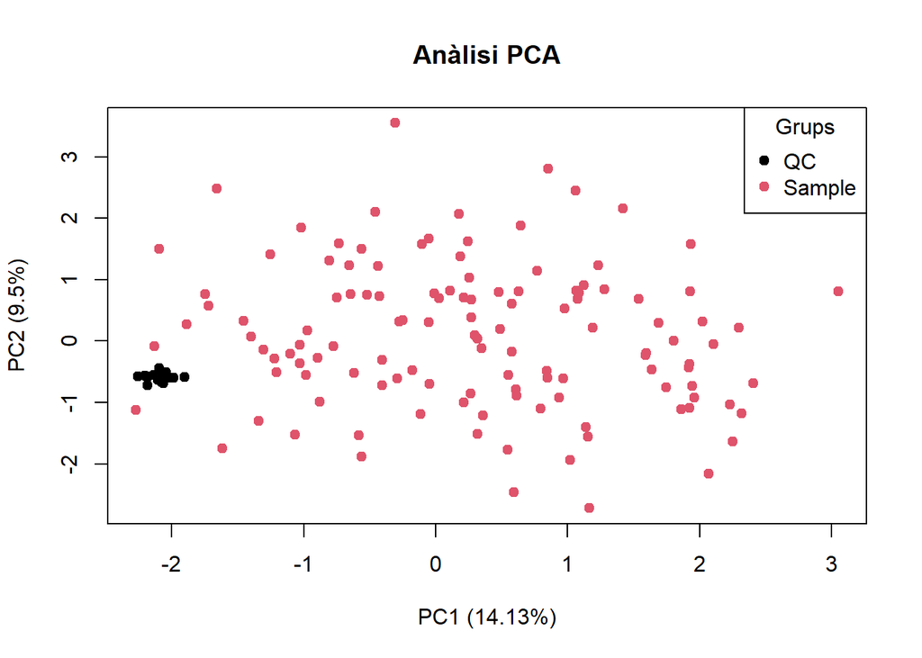

```r
group_label <- colData(f_se_gcancer)[,1]
unique_groups <- unique(group_label)

plot(pca_df$PC1, pca_df$PC2, col = as.factor(group_label),
     xlab = paste0("PC1 (", round((v[1]*100), 2), "%)"), ylab = paste0("PC2 (", round((v[2]*100), 2), "%)"), pch = 19, main = "Anàlisi PCA")
legend("topright", legend = unique_groups, col = as.factor(group_label), pch = 19, title = "Grups")
```